# Basic robustness concepts of statistics

Vince Carey

June 14, 2017

Road map:

- simulation of test size and power
- effects of sample contamination
- resistant statistics: robustification of key statistical procedures
- measuring influence of observations in DESeq2

# Some code to enter in your workspace

Mystery functions?

```r
ts_zpm = function(d) sqrt(length(d))*mean(d)/sd(d)
```

```r
contam1 = function(x, slip=5) {x[1] = x[1]+slip; x}
```

# Try them out

```r
set.seed(12345)
X = rnorm(50)
ts_zpm(X)
```

```
## [1] 1.157889
```

```r
ts_zpm(contam1(X))
```

```
## [1] 1.479476
```

```r
ts_zpm(contam1(X,100))
```

```
## [1] 1.082075
```

# The concept of the critical region

- Wolfgang: count events and check whether the count falls into a region prescribed to have low probability under the null hypothesis
- The probabilities of regions are prescribed by the binomial distribution
- We need probabilities and principles for choosing the critical region
  - symmetric about null value?
  - represent a specific direction of effect (one-sided?)
  - based on theory or simulation?

# Assumptions underlying a test procedure

- *Exact* critical regions based on finite sample distribution of a statistic
  - $t$, Wilcoxon
  - the parent distribution must satisfy certain conditions
    - data are a random sample from homogeneous population (iid)
    - for $t$: parent is Gaussian
    - for Wilcoxon: parent is continuous, finite variance (?)
- *Approximate* critical regions based on large sample theory
  - how large is large enough?
  - data are a random sample from homogeneous population (iid)
- *Approximate* critical regions based on simulation
  - the generative distribution accurately represents variation underlying the experiment or observations

# Computing and reporting a t test for a simple hypothesis

```r
set.seed(12345)
X = rnorm(50)
tst = t.test(X)
tst
```

```
##
##  One Sample t-test
##
## data:  X
## t = 1.1579, df = 49, p-value = 0.2525
## alternative hypothesis: true mean is not equal to 0
## 95 percent confidence interval:
##  -0.1320800  0.4912126
## sample estimates:
## mean of x
## 0.1795663
```

# Components of the result

```r
str(tst)
```

```
## List of 9
##  $ statistic  : Named num 1.16
##   ..- attr(*, "names")= chr "t"
##  $ parameter  : Named num 49
##   ..- attr(*, "names")= chr "df"
##  $ p.value    : num 0.253
##  $ conf.int   : atomic [1:2] -0.132 0.491
##   ..- attr(*, "conf.level")= num 0.95
##  $ estimate   : Named num 0.18
##   ..- attr(*, "names")= chr "mean of x"
##  $ null.value : Named num 0
##   ..- attr(*, "names")= chr "mean"
##  $ alternative: chr "two.sided"
##  $ method     : chr "One Sample t-test"
##  $ data.name  : chr "X"
##  - attr(*, "class")= chr "htest"
```

# The structure of the t statistic: a ratio of measures of location and dispersion

```r
tst$statistic  # from R
```

```
##        t
## 1.157889
```

```r
sqrt(50)*mean(X)/sd(X) # by hand
```

```
## [1] 1.157889
```

# Simulating the distribution of t under the null hypothesis: $X \sim N(0,\sigma^2)$

```r
set.seed(12345)
simdist = replicate(10000,  ts_zpm( rnorm(50) ))
head(simdist)
```

```
## [1]  1.15788926  1.92818028 -0.08173422  0.82143100  0.39880144 -1.21706025
```

# Simulated data and theoretical density

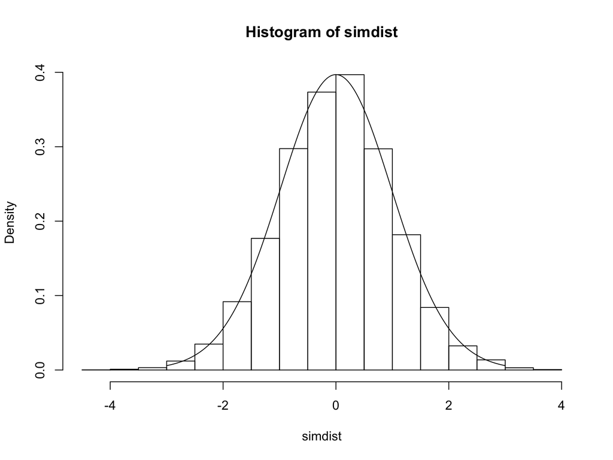

```r
hist(simdist, freq=FALSE)
lines(seq(-3,3,.01), dt(seq(-3,3,.01), 49))
```

# The one-sided p-value for $\hat{t}$ = 1.1579

simulated:

```r
mean(simdist > 1.1579)
```

```
## [1] 0.123
```

theoretical (exact):

```r
integrate(function(x) dt(x,49), 1.1579, Inf)$value
```

```
## [1] 0.1262589
```

# What if there is a contaminated observation?

```r
contsim = replicate(10000,
    ts_zpm( contam1( rnorm(50) ) ) )
critval_1sided = qt(.95, 49)
mean(simdist > critval_1sided) # uncontaminated
```

```
## [1] 0.0483
```

```r
mean(contsim > critval_1sided) # contaminated
```

```
## [1] 0.0946
```

# Can we fix this?

```r
library(parody)
robust_t = function(x) {
 outchk = calout.detect(x, method="GESD")
 if (!is.na(outchk$ind[1])) x = x[-outchk$ind]
 sqrt(length(x))*mean(x)/sd(x)
}
set.seed(12345)
contsim_r = replicate(10000,
    robust_t( contam1( rnorm(50) ) ) )
mean(contsim_r > critval_1sided) # robust test on contaminated
```

```
## [1] 0.0531
```

# Recap

- the one-sided one sample t test for $H_0: \mu = 0$ involves
  - $n$, $\bar{X}$, $s$ to form the test statistic, and
  - the $t$ density to form critical values
- simulation from the null distribution can be used to obtain an empirical p value
- simulation from the contaminated distribution with a single observation shifted by $5\sigma$ leads to a Type I error rate (using the standard $t$ critical value for $\alpha = 0.05$) of 0.095
- robustification of the test statistic using calibrated outlier removal can restore (approximately) the nominal Type I error rate
  - can’t conclude too much from this example, of course … there is considerable theoretical literature on sensitivity of tests to contamination
  - the t test is described as ‘robust’ in many texts, referring to
    - insensitivity to violation of the assumption of Gaussian population
    - insensitivity to violation of the assumption of equal variances in the two-sample case

# Power to reject $H_0:\mu = 0$ when $\mu = 0.4$

```r
power.t.test(n=50, type="one.sample",
   alt="one.sided", delta=.4)
```

```
##
##      One-sample t test power calculation
##
##               n = 50
##           delta = 0.4
##              sd = 1
##       sig.level = 0.05
##           power = 0.8737242
##     alternative = one.sided
```

```r
# empirical
mean( replicate(10000,
    ts_zpm(rnorm(50, .4))>qt(.95, 49)) )
```

```
## [1] 0.8764
```

# Effect of contamination: a single large contaminant can slash power

```r
mean( replicate(10000, ts_zpm(
     contam1(rnorm(50, .4), slip=25))>qt(.95, 49)) )
```

```
## [1] 0.5834
```

Exercises:

- plot power against size of slip
- show that calibrated outlier removal can restore power lost with contamination

# Sample median is a resistant estimator of location

We’ll use a series of outlier magnitudes (0:10) and summarize distributions of estimators

```r
set.seed(12345)
mns <- sapply(0:10, function(o)
  median(replicate(5000, mean(contam1(rnorm(50),o)))))
set.seed(12345)
meds <- sapply(0:10, function(o)
  median(replicate(5000, median(contam1(rnorm(50),o)))))
```

# Note sensitivity of mean

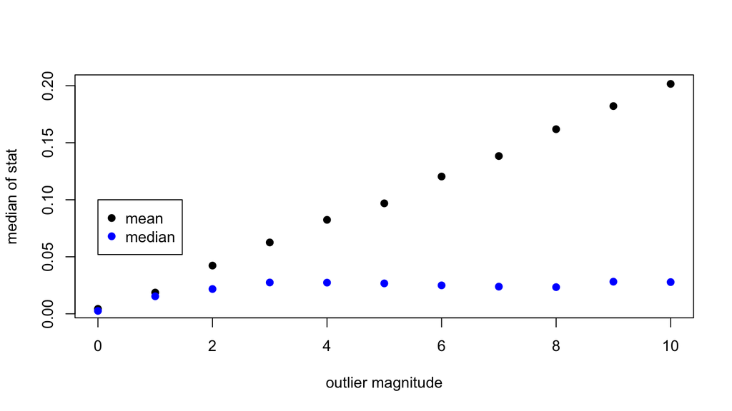

```r
plot(0:10, mns, xlab="outlier magnitude", ylab="median of stat",
  pch=19)
points(0:10, meds, pch=19, col="blue")
legend(0, .1, pch=19, col=c("black", "blue"), legend=c("mean", "median"))
```

# Sample MAD is a resistant estimator of dispersion

```r
set.seed(12345)
sds <- sapply(0:10, function(o)
  median(replicate(5000, sd(contam1(rnorm(50),o)))))
set.seed(12345)
mads <- sapply(0:10, function(o)
  median(replicate(5000, mad(contam1(rnorm(50),o)))))
```

# Note sensitivity of SD

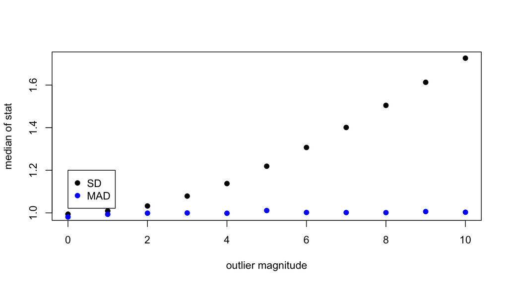

```r
plot(0:10, sds, xlab="outlier magnitude", ylab="median of stat",
  pch=19)
points(0:10, mads, pch=19, col="blue")
legend(0, 1.2, pch=19, col=c("black", "blue"), legend=c("SD", "MAD"))
```

# Recap

# Exercises

- Generalize `contam1()` to help demonstrate the breakdown concept
- Assess the robustness of size and power of rank-based tests (such as Wilcoxon’s signed rank test) to contamination by outliers.
- Note that dsignrank, qsignrank are available.

```r
qsignrank(.95, 50)
```

```
## [1] 808
```

```r
set.seed(12345)
wilcox.test(rnorm(50, .4))$statistic
```

```
##   V
## 977
```

# Deficiencies of scalar summaries

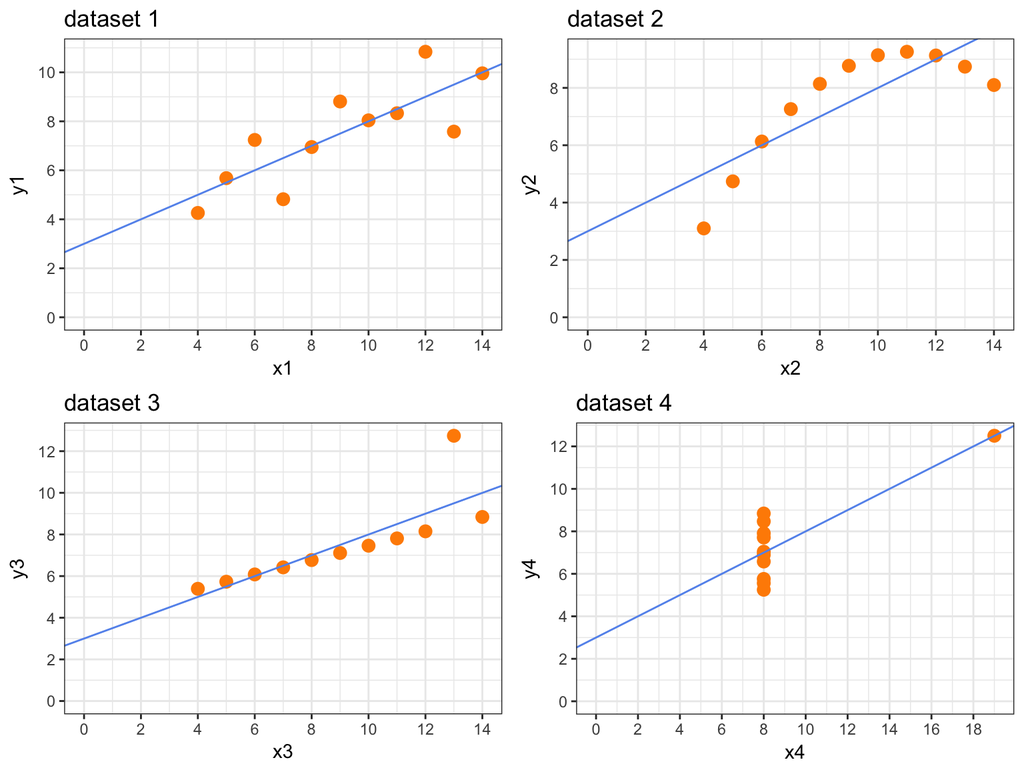

# Anscombe’s data

Show that the (x,y) pairs have identical

```
- marginal means
- marginal SDs
- correlation coefficients
- linear regressions of y on x
```

Use MASS::rlm to get a model for y3, x3 that fits the majority of points exactly

# Outliers in RNA-seq analysis

- DESeq2 has extensive discussion of Cook’s distance for identifying and reducing effects of apparent outliers
- Let’s get a feel for what Cook’s distance is: source(“shi.R”); docook()

# Simulating an RNA-seq experiment

```r
suppressMessages({set.seed(12345)
library(DESeq2)
S1 = makeExampleDESeqDataSet(betaSD=.75)
D1 = DESeq(S1)
R1 = results(D1)})
```

```r
summary(R1)
```

```
##
## out of 997 with nonzero total read count
## adjusted p-value < 0.1
## LFC > 0 (up)     : 99, 9.9%
## LFC < 0 (down)   : 95, 9.5%
## outliers [1]     : 2, 0.2%
## low counts [2]   : 211, 21%
## (mean count < 6)
## [1] see 'cooksCutoff' argument of ?results
## [2] see 'independentFiltering' argument of ?results
```

# Exercises

- Find the outliers labeled by DESeq2
- Are these really suspect?
- For the homogeneous simulation process demonstrated here, estimate the frequency of outlier labeling by the default rules
- Define a process for injecting aberrant counts and assess the accuracy of the default rules for identifying them. How do the rules contribute to validity and power of the basic testing procedure?

# Conclusion

- Robustness is commonly cited as a property of new methodologies
  - the term is often used vaguely
- In statistics, there is robustness of validity (Type I error rate is maintained despite failure of certain assumptions) and robustness of efficiency (power does not decline in the presence of failure of certain assumptions)
- *Resistance* is a related concept: a fraction of *arbitrarily aberrant* values may be present, but their effect on estimation or inference is bounded
- Outlier labeling is carefully studied for generations; the outliers may be the most interesting points in your data
- Learn how to use simulation, with specific attention to realism and flexibility of implementation, so that you can explore a variety of scenarios